# Answers to exercises

## Exercise 1

- use the dataset found in `system.file("shape/nc.shp", package="sf")`
- Read this dataset with `sf::st_read` (or `sf::read_sf`)

```r
library(sf)
nc = read_sf(system.file("shape/nc.shp", package="sf"))
```

- plot the dataset, then plot the second attribute

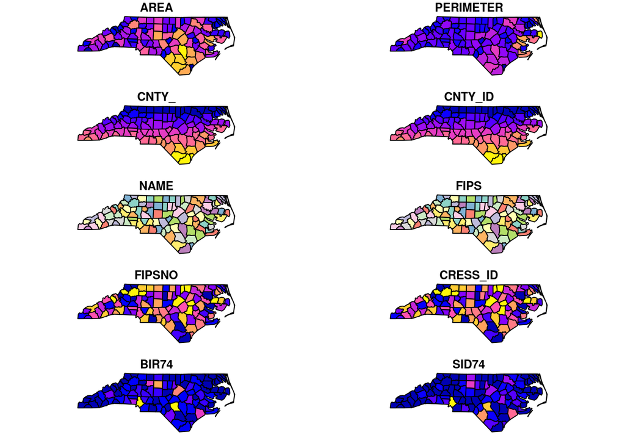

```r
plot(nc)
```

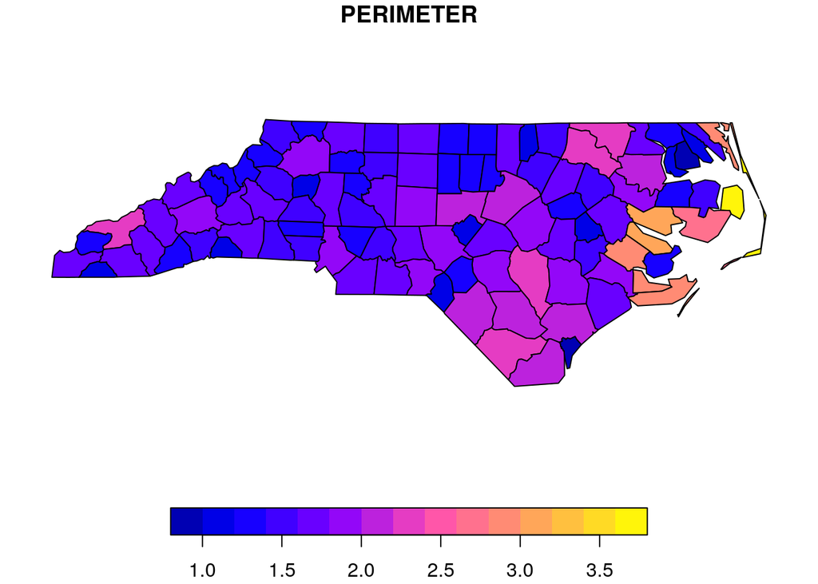

```r
plot(nc[,2])
```

```r
# or, e.g.
# library(tidyverse)
# nc %>% select(2) %>% plot
```

- try to manipulate the color scheme and color breaks

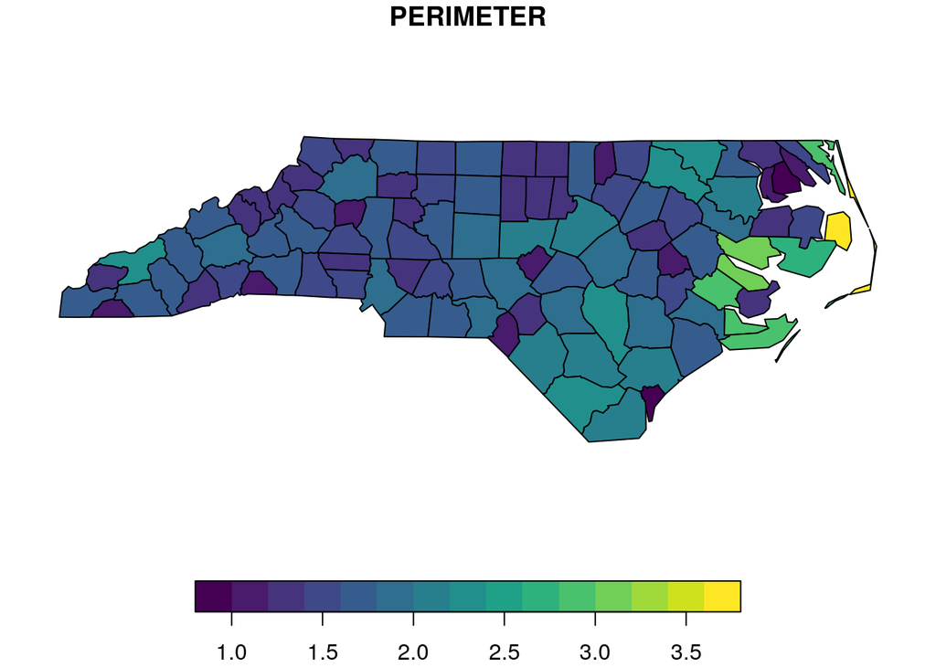

```r
plot(nc[,2], pal = viridis::viridis) # note that this is a function, not a set of colors
```

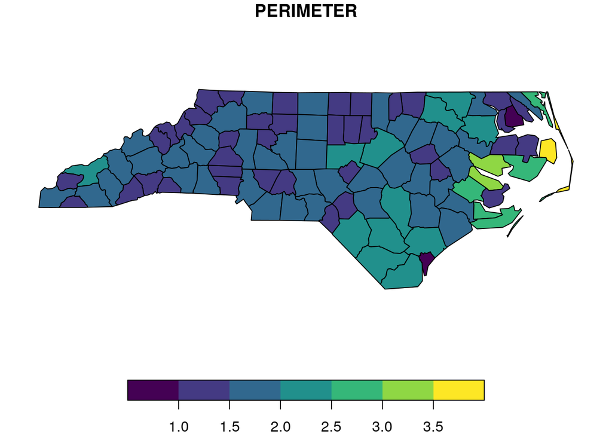

```r
plot(nc[,2], nbreaks = 5, pal = viridis::viridis)  # note that we don't get exactly 5, because of "pretty" style
```

- plot the first 20 features of the dataset

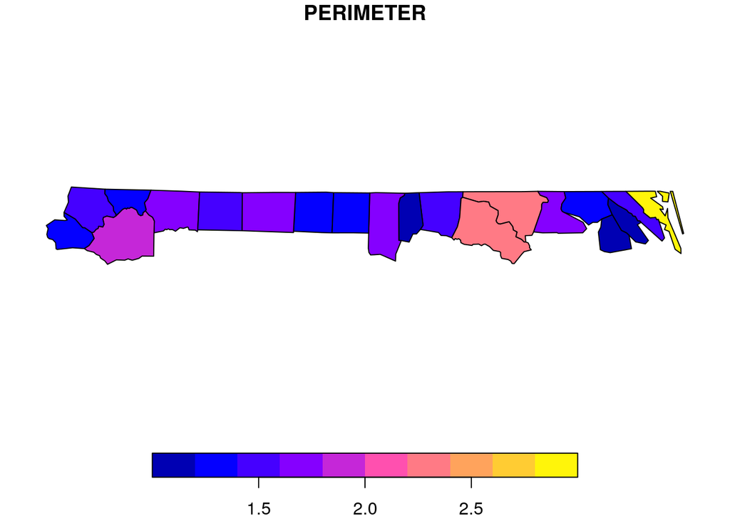

```r
plot(nc[1:20,2])
```

- create a plot with axes

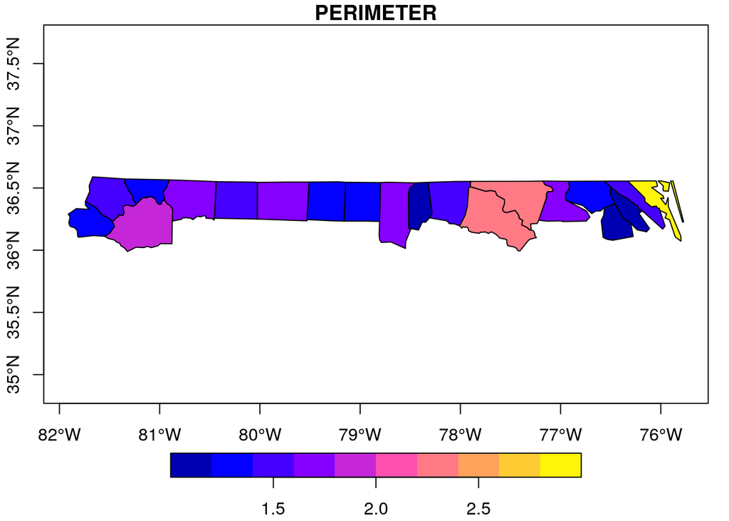

```r
plot(nc[1:20,2], axes = TRUE)
```

- what is the coordinate reference system of the dataset?

```r
st_crs(nc)
```

```
## Coordinate Reference System:
##   EPSG: 4267
##   proj4string: "+proj=longlat +datum=NAD27 +no_defs"
```

- For the `nc` dataset, compute the area of the polygons with `st_area`
- compare the areas with the `AREA` field in the dataset; is there a discrepancy?

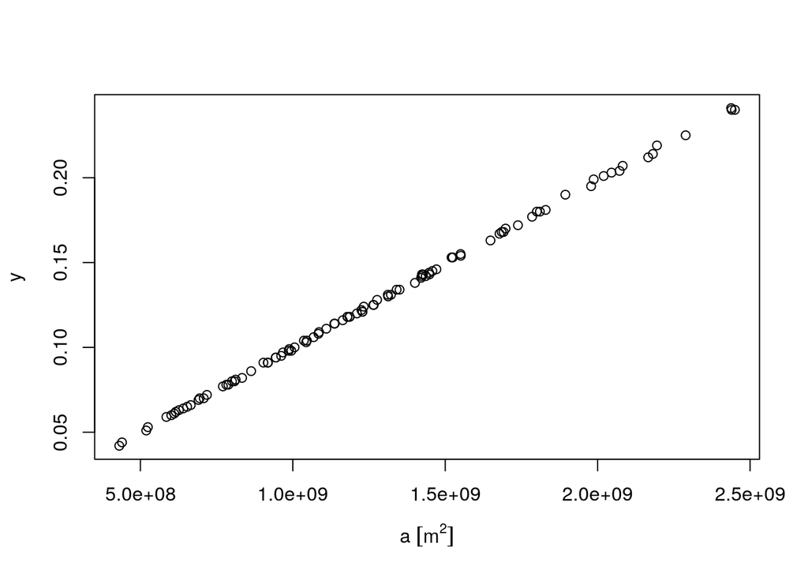

```r
a = st_area(nc)
plot(a, nc$AREA)
```

- select the polygon that intersects with `POINT (-81.49826 36.4314)`

```r
pt = st_as_sfc("POINT (-81.49826 36.4314)", crs = st_crs(nc))
nc[pt,]
```

```
## although coordinates are longitude/latitude, st_intersects assumes that they are planar
```

```
## Simple feature collection with 1 feature and 14 fields
## geometry type:  MULTIPOLYGON
## dimension:      XY
## bbox:           xmin: -81.74107 ymin: 36.23436 xmax: -81.23989 ymax: 36.58965
## epsg (SRID):    4267
## proj4string:    +proj=longlat +datum=NAD27 +no_defs
## # A tibble: 1 x 15
##    AREA PERIMETER CNTY_ CNTY_ID NAME  FIPS  FIPSNO CRESS_ID BIR74 SID74
##   <dbl>     <dbl> <dbl>   <dbl> <chr> <chr>  <dbl>    <int> <dbl> <dbl>
## 1 0.114      1.44  1825    1825 Ashe  37009  37009        5  1091     1
## # … with 5 more variables: NWBIR74 <dbl>, BIR79 <dbl>, SID79 <dbl>,
## #   NWBIR79 <dbl>, geometry <MULTIPOLYGON [°]>
```

## Exercises (2)

- Read the file `system.file("tif/L7_ETMs.tif", package = "stars")` with `stars::read_stars`
- print the dataset, and describe what it contains
- plot the dataset; how are the color breaks chosen?

```r
library(stars)
r = read_stars(system.file("tif/L7_ETMs.tif", package = "stars"))
r
```

```
## stars object with 3 dimensions and 1 attribute
## attribute(s):
##   L7_ETMs.tif
##  Min.   :  1.00
##  1st Qu.: 54.00
##  Median : 69.00
##  Mean   : 68.91
##  3rd Qu.: 86.00
##  Max.   :255.00
## dimension(s):
##      from  to  offset delta                       refsys point values
## x       1 349  288776  28.5 +proj=utm +zone=25 +south... FALSE   NULL [x]
## y       1 352 9120761 -28.5 +proj=utm +zone=25 +south... FALSE   NULL [y]
## band    1   6      NA    NA                           NA    NA   NULL
```

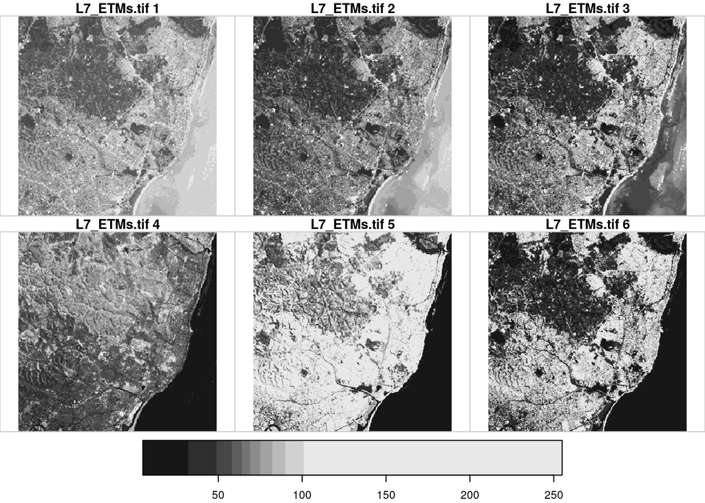

```r
plot(r)
```

The color breaks are chosen by the default method for `breaks`, which is “quantile”; this means that (regularly chosen) quantiles of the pixel values are chosen; this means that the map shows equal amounts of each color.

- find the maximum pixel value for each of the bands (`st_apply`)

```r
st_apply(r, 3, max)
```

```
## stars object with 1 dimensions and 1 attribute
## attribute(s):
##       max
##  Min.   :255
##  1st Qu.:255
##  Median :255
##  Mean   :255
##  3rd Qu.:255
##  Max.   :255
## dimension(s):
##      from to offset delta refsys point values
## band    1  6     NA    NA     NA    NA   NULL
```

- find and plot the maximum reflectance over all bands for all pixels

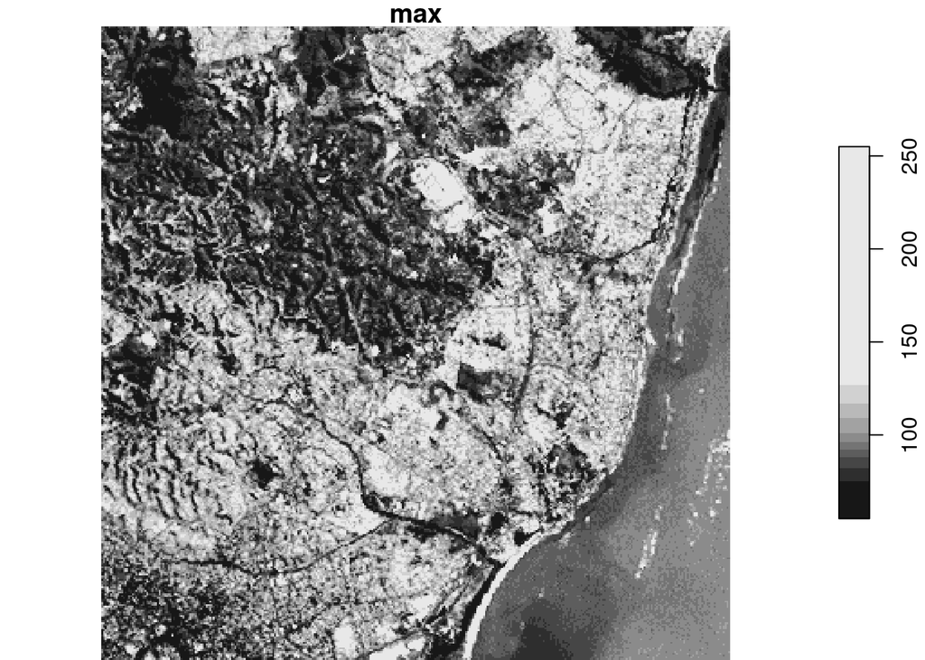

```r
plot(st_apply(r, 1:2, max))
```

* find and plot the mean reflectance over all bands for all pixels

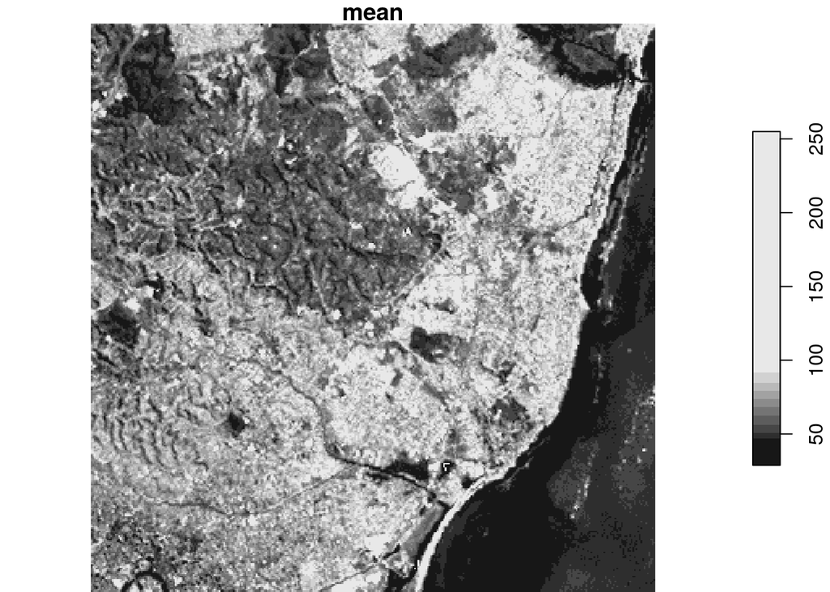

```r
plot(st_apply(r, 1:2, mean))
```

* plot the subset of these data with the first 10 rows, the second 10 colums, and the last 3 bands

```r
r[,1:10, 11:20, 4:6]
```

```
## stars object with 3 dimensions and 1 attribute
## attribute(s):
##   L7_ETMs.tif
##  Min.   : 19.00
##  1st Qu.: 55.00
##  Median : 72.00
##  Mean   : 70.13
##  3rd Qu.: 83.00
##  Max.   :130.00
## dimension(s):
##      from to  offset delta                       refsys point values
## x       1 10  288776  28.5 +proj=utm +zone=25 +south... FALSE   NULL [x]
## y      11 20 9120761 -28.5 +proj=utm +zone=25 +south... FALSE   NULL [y]
## band    4  6      NA    NA                           NA    NA   NULL
```

- use `st_crop` to crop the dataset to the area 300 m around `POINT (293749.5 9115745)`

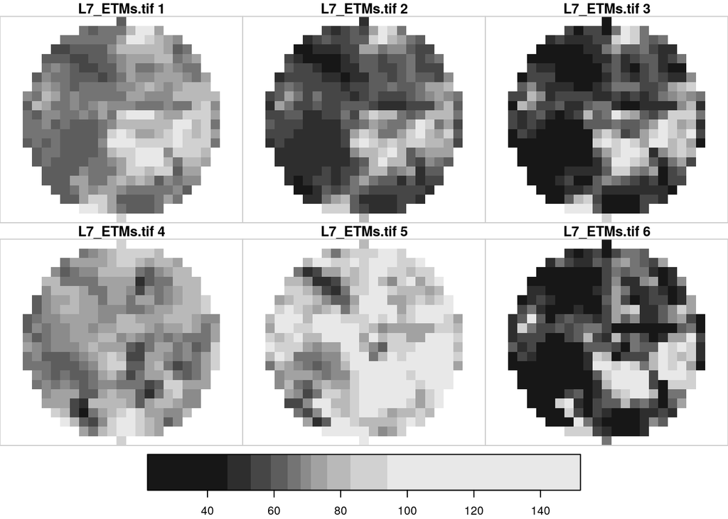

```r
pt = st_as_sfc("POINT (293749.5 9115745)", crs = st_crs(r))
cr = st_crop(r, st_buffer(pt, units::set_units(300, m)))
plot(cr)
```

* is this cropped dataset still a (rectangular) raster?

yes: the values outside the circle are simply set to `NA`, and are not plotted.

## Exercise 3

```r
data(DE_RB_2005, package = "gstat")
library(spacetime)
library(stars)
s = st_as_stars(as(DE_RB_2005, "STFDF"))
# select a single day, omit NA values:
s1 = na.omit(st_as_sf(s[,,100]))
names(s1)[1] = "PM10"
library(gstat)
variogram(PM10~1, s1)
```

```
##     np      dist     gamma dir.hor dir.ver   id
## 1    4  18898.55  7.020488       0       0 var1
## 2   23  34364.92  6.440393       0       0 var1
## 3   32  56345.09 11.255562       0       0 var1
## 4   39  77732.46  7.906209       0       0 var1
## 5   55  99506.37  8.341365       0       0 var1
## 6   71 122440.26  9.902675       0       0 var1
## 7   85 143636.56 15.158993       0       0 var1
## 8   80 164572.07 13.839935       0       0 var1
## 9   91 187694.48 12.821504       0       0 var1
## 10  88 209843.86 14.708895       0       0 var1
## 11  98 231000.08 17.078920       0       0 var1
## 12 110 254882.02 22.609394       0       0 var1
## 13 104 276259.20 22.452120       0       0 var1
## 14 101 297576.88 18.176579       0       0 var1
## 15  91 320326.70 28.031442       0       0 var1
```

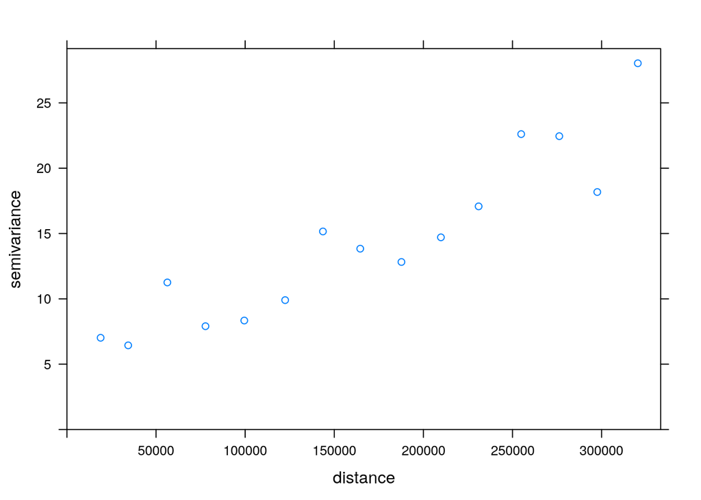

```r
plot(variogram(PM10~1, s1))
```

Building on the above dataset, create out plot where:

- setting the `cutoff` to a much larger, and a much smaller value

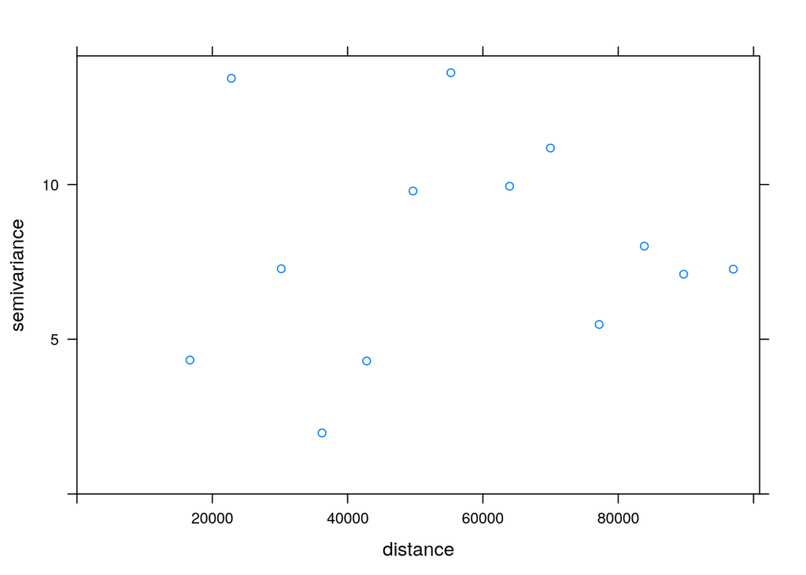

```r
plot(variogram(PM10~1, s1, cutoff = 1e5))
```

- setting the `width` argument to a larger and smaller value

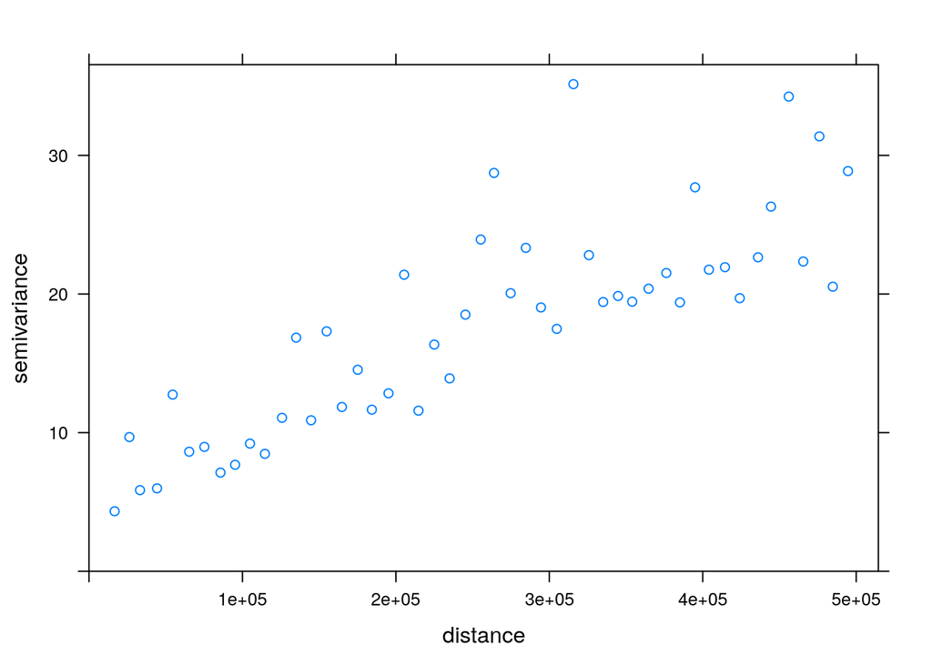

```r
plot(variogram(PM10~1, s1, width =  10000, cutoff = 5e5))
```

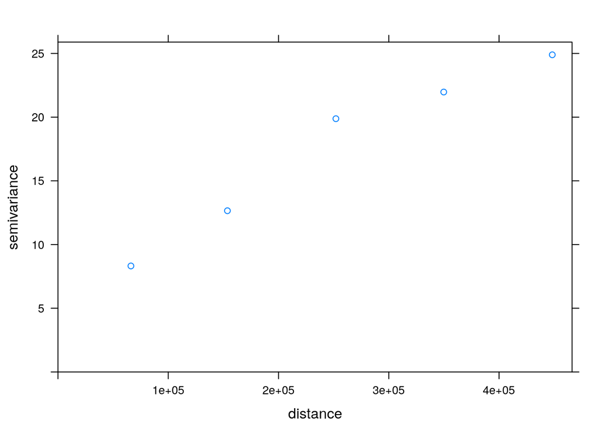

```r
plot(variogram(PM10~1, s1, width = 100000, cutoff = 5e5))
```

- the number of point pairs involved is also shown in the plot

[figure not shown]

```r
plot(variogram(PM10~1, s1, width = 100000, cutoff = 5e5, plot.numbers = TRUE))
```

- setting `cloud=TRUE` - what do the points in this plot represent? (hint: plot the number of point pairs)

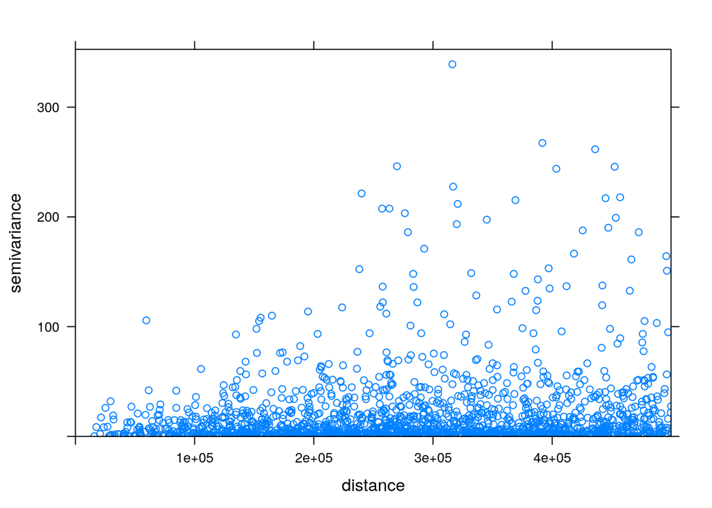

```r
plot(variogram(PM10~1, s1, cutoff = 5e5, cloud = TRUE)) # width ignored
```

- Save a variogram you like to an object, and fit a model to it using `fit.variogram`; use `vgm()` to list the possible models and `show.vgms()` to get an idea how they look.

```r
v = variogram(PM10~1, s1)
init = vgm(20, "Sph", 300000, 5)
f = fit.variogram(v, init)
```

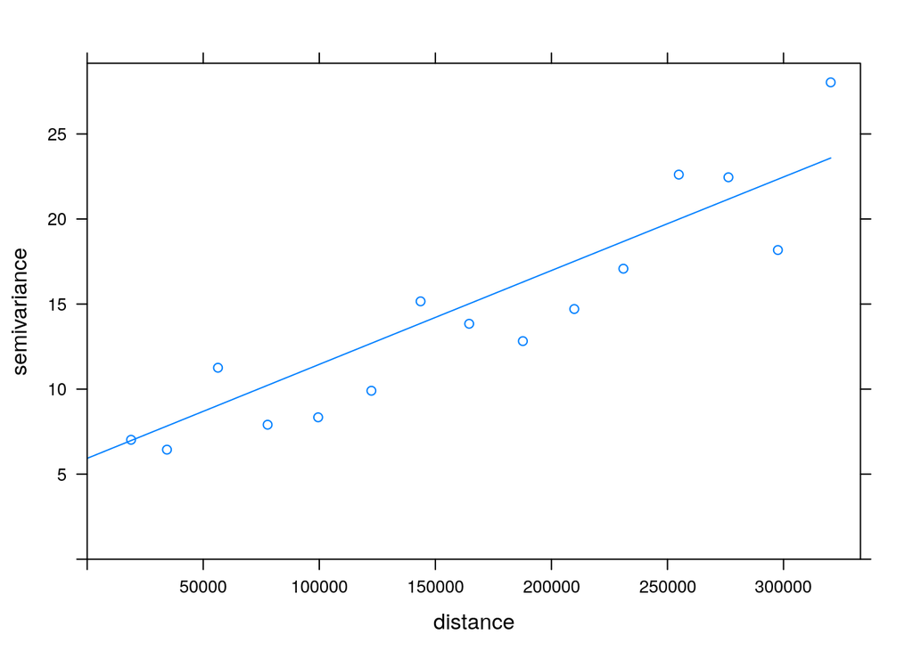

```r
plot(v, f)
```

- If you get errors on fit, don’t worry:
  - plot the variogram with fitted model (like: `plot(v, fit)`, and examine how it looks
  - try to choose better initial values for nugget (offset), sill (final level), range (distance where correlation no longer increases)

## Exercises 4

Compare the ranges of the kriging and idw map, and the range of the PM10 data. Explain differences and correspondences.

```r
# load German boundaries
data(air, package = "spacetime")
de <- st_transform(st_as_sf(DE_NUTS1), 32632)
bb = st_bbox(de)
dx = seq(bb[1], bb[3], 10000)
dy = seq(bb[4], bb[2], -10000) # decreases!
st_as_stars(matrix(0., length(dx), length(dy))) %>%
  st_set_dimensions(1, dx) %>%
  st_set_dimensions(2, dy) %>%
  st_set_crs(32632) -> grd

i = idw(PM10~1, s1, grd)
```

```
## [inverse distance weighted interpolation]
```

```r
v = variogram(PM10~1, s1)
f = fit.variogram(v, vgm(20, "Lin", 0, 4))
kr = krige(PM10~1, s1, grd, f)
```

```
## [using ordinary kriging]
```

```r
range(i[["var1.pred"]])
```

```
## [1]  4.03311 29.36141
```

```r
range(kr[["var1.pred"]])
```

```
## [1]  7.254416 24.375381
```

```r
range(s1$PM10)
```

```
## [1]  3.625 29.667
```

Kriging smoothes much more, mostly because the variogram model used (here) has a considerable relative nugget (nugget component as fraction of the total variance)

Examine the kriging variance error map.

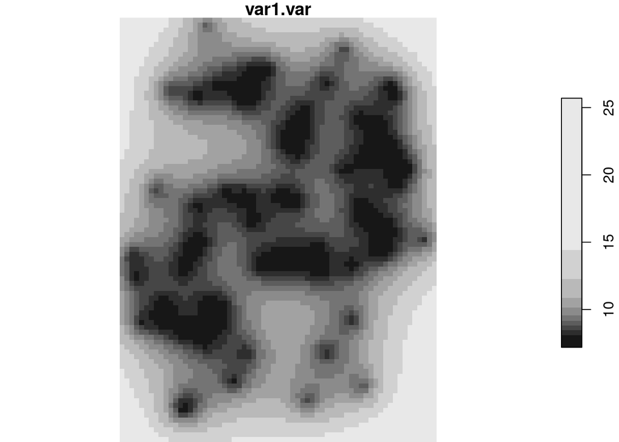

```r
plot(kr[2])
```

Compute a standard error map by taking the square root of the kriging variance

```r
kr$stderr = sqrt(kr$var1.var)
```

Plot this map with the data points overlayed: can you explain the pattern in the errors?

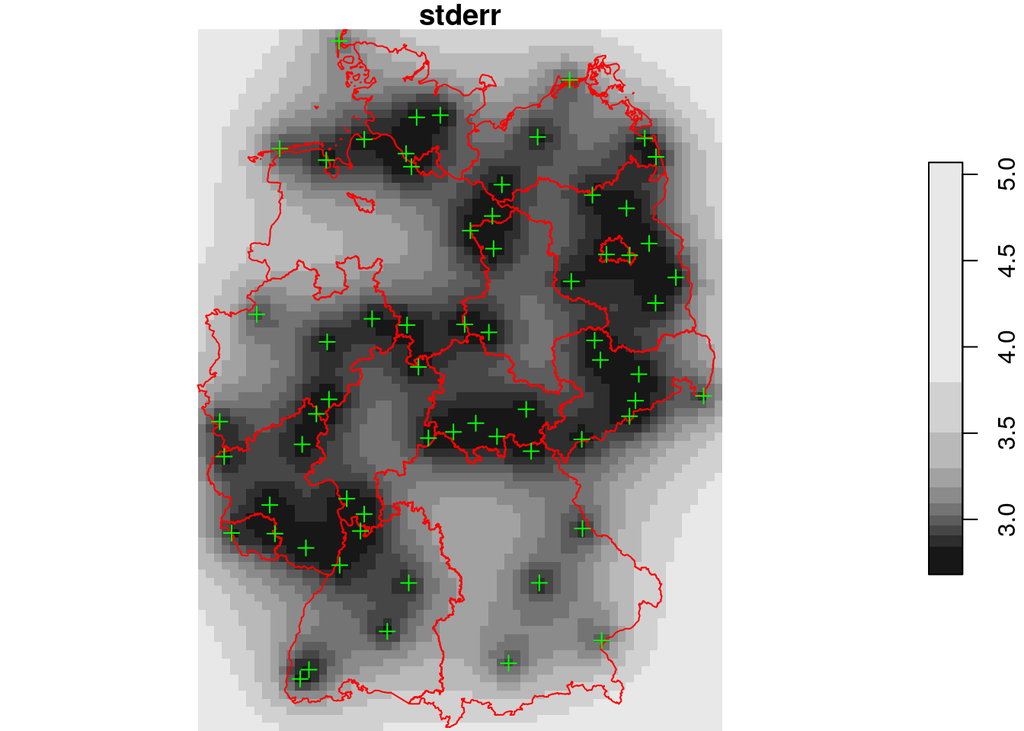

```r
plot(kr["stderr"], reset = FALSE)
plot(st_geometry(de), add = TRUE, col = NA, border = 'red')
plot(s1, add = TRUE, col = 'green', pch = 3)
```

Repeat the exercise with the same linear model but with a zero nugget effect, and compare the ranges again.

```r
# brute-force: setting the nugget to zero:
f$psill[1] = 0
# somewhat "nicer": fitting the same model, but without a nugget:
f = fit.variogram(v, vgm(20, "Lin", 0))
kr0 = krige(PM10~1, s1, grd, f)
```

```
## [using ordinary kriging]
```

```r
range(kr0[[1]])
```

```
## [1]  3.999323 29.490683
```

Repeat the exercise with the a spherical model with a short range and zero nugget, and compare the ranges again.

```r
# use a short range spherical model, range 100 km, zero nugget:
f = vgm(20, "Sph", 100000)
kr.sph = krige(PM10~1, s1, grd, f)
```

```
## [using ordinary kriging]
```

```r
range(kr.sph[[1]])
```

```
## [1]  4.146075 28.374769
```

Repeat the exercise with the a pure nugget effect model (e.g., vgm(20, “Nug”, 0)), and compare the ranges again.

```r
# fit a pure nugget model:
(f = fit.variogram(v, vgm(1, "Nug", 0)))
```

```
##   model    psill range
## 1   Nug 10.16699     0
```

```r
kr.nug = krige(PM10~1, s1, grd, f)
```

```
## [using ordinary kriging]
```

```r
range(kr.nug[["var1.pred"]])
```

```
## [1] 12.50885 12.50885
```

```r
mean(s1$PM10)
```

```
## [1] 12.50885
```

```r
range(kr.nug[["var1.var"]])
```

```
## [1] 10.3234 10.3234
```

```r
var(s1$PM10)
```

```
## [1] 20.12527
```

```r
mean(variogram(PM10~1, s1, cloud=TRUE)$gamma)
```

```
## [1] 16.55404
```

```r
mean(variogram(PM10~1, s1, cloud=TRUE, cutoff = 1e6)$gamma)
```

```
## [1] 20.12527
```

Compute (approximate) 95% prediction intervals by adding +/- 2 standard errors to the kriging

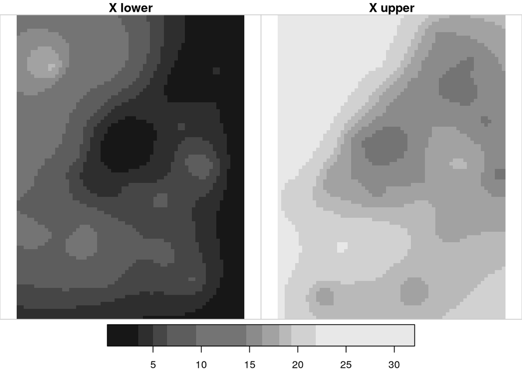

```r
kr$stderr = sqrt(kr$var1.var)
kr$upper = kr$var1.pred + 2 * kr$stderr
kr$lower = kr$var1.pred - 2 * kr$stderr
plot(merge(kr[c("lower", "upper")]))
```

Create a map with locations where the threshold of 25 has been exceeded, or might have been exceeded (is inside the prediction interval)

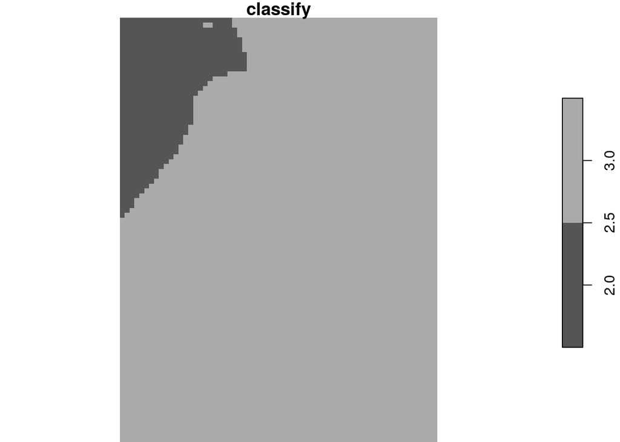

```r
kr$classify = ifelse(kr$lower > 25, 1, ifelse(kr$upper < 25, 3, 2))
plot(kr["classify"]) # legend 1: above 25, 2: ?, 3: below 25
```

## Exercises 5

- Carry out a block kriging, setting `block=c(10000,10000)` to estimate 10 km x 10 km block mean values
- Compare the kriged values to those obtained by point kriging, compare the ranges
- Compare the standard errors between point and block kriging

```r
f = fit.variogram(v, vgm(20, "Lin", 0, 4))
kr = krige(PM10~1, s1, grd, f) # point kriging
```

```
## [using ordinary kriging]
```

```r
bl = krige(PM10~1, s1, grd, f, block = c(10000, 10000)) # block kriging
```

```
## [using ordinary kriging]
```

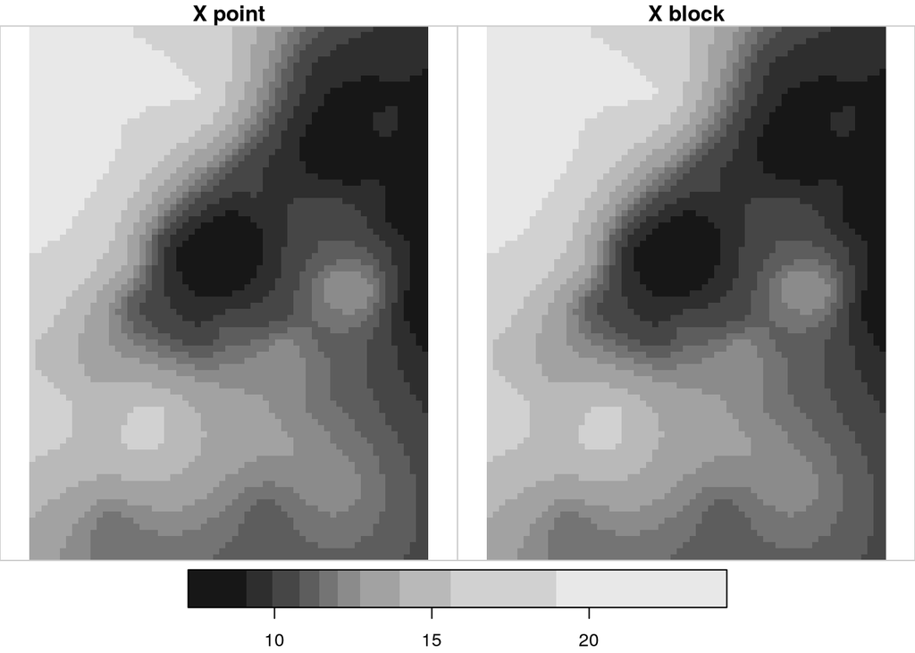

```r
kr$point = kr$var1.pred
kr$block = bl$var1.pred
plot(merge(kr[c("point", "block")]))
```

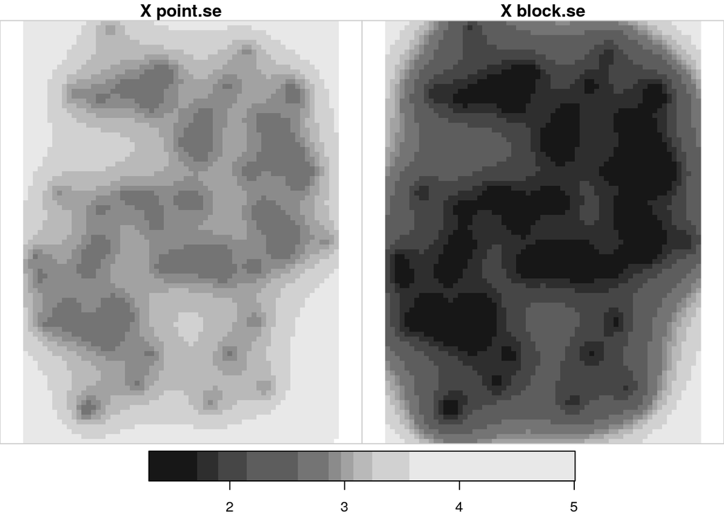

```r
kr$point.se = sqrt(kr$var1.var)
kr$block.se = sqrt(bl$var1.var)
plot(merge(kr[c("point.se", "block.se")]))
```

```r
range(kr$point)
```

```
## [1]  7.254416 24.375381
```

```r
range(kr$block)
```

```
## [1]  7.282503 24.344914
```

```r
range(kr$point.se)
```

```
## [1] 2.681161 5.069061
```

```r
range(kr$block.se)
```

```
## [1] 1.295284 4.488885
```